# Apendice_JoanCabanas_PEC1_ADO

Joan Cabanas Ballbe

2025-03-27

[figure not shown]

Si quieres accder a la UOC haz clic en enlace:http:www.uoc.edu.

# **Máster en Bioestadística y Bioinformatica**

# Análisis de datos ómicos (M0-157)

## Primera prueba de evaluación continua.

### **Instalación.**

Primero es necesario una instalación previa con todos los paquetes empleados en el análisis.

Paquestes necesarios a instalar.

```r
> # Instalacion. En esta celda se muestra el codigo necesario pero no se ejecuta, si requiere su ejecucion intrudizca "eval=TRUE".
> install.packages("BiocManager")
> BiocManager::install("SummarizedExperiment")
> BiocManager::install("tidyverse")
> install.packages("readr")
> install.packages("ggplot2")
> install.packages("ggfortify")
```

#### Carga paquetes.

A continuación, cargamos todos los paquetes necesarios previamente instalados.

```r
> # Cargamos en la memoria los siguientes paquetes.
> # CRAM
> library(readr) # Nos permite leer los archivos.
> library(ggplot2)     # Para la creaccion de graficos con ggplot.
> library(ggfortify)
>
> # Bioconductor
> library(SummarizedExperiment)
> library(tidyverse)
```

### 1. Descargamos los datos de Metabolomics Workbench.

En este caso hemos accedido a los archivos mediante el repositorio GitHub proporcionado **[ref: 1]**. Una vez que tenemos los archivos descargados, podemos proceder a cargar los datos en el entorno.

En nuestro caso los datos escoguidos pertenecen al estudio **ST000291**.

(es importante añadir que los datos se encuentran en tres ficheros en formato .csv y la información esta separada por “;”)

```r
> # Lectura de los tres ficheros.
>
> # Cargar datos de caracteristicas.
> features <- read.csv("Ficheros_PEC1/features.csv", row.names = 1, sep = ";")
>
> # Cargar metadatos de las muestras.
> metadata <- read.csv("Ficheros_PEC1/metadata.csv", row.names = 1, sep = ";")
>
> # Cargar nombres de metabolitos.
> metabolite_names <- read.csv("Ficheros_PEC1/metaboliteNames.csv", row.names = 1, sep = ";" )
```

```r
> # Comprovamos que se hayan cargado los datos correctamente, con las dimensiones correctas.
> dim(features)
```

```
[1] 1541   45
```

```r
> dim(metadata)
```

```
[1] 45  2
```

```r
> dim(metabolite_names)
```

```
[1] 1541    3
```

Análisis de la concordancia entre los datos de los distintos ficheros, se verifica que los nombres de las filas y columnas coincidan.

```r
> # Verificamos la concordancia entre los datos, que los nombres de las muestras coincidan.
> all(rownames(metadata) %in% colnames(features))  # Debe devolver TRUE.
```

```
[1] FALSE
```

```r
> # Analisis mas detallado.
> # Revisamos los nombres de las columnas de features, deben coincidir con las filas de metadata.
> head(colnames(features))
```

```
[1] "b1"  "b10" "b11" "b12" "b13" "b14"
```

```r
> # Revisamos los nombres de las filas de metadata, deben coincidir con las columnas de features.
> head(rownames(metadata))
```

```
[1] "1" "2" "3" "4" "5" "6"
```

```r
> # Revisamos los nombres de las filas de features, deben coincidir con las filas de metabolite_names.
> head(rownames(features))
```

```
[1] "443489"   "107754"   "9543071"  "11011465" "5281160"  "440341"
```

```r
> # Revisamos los nombres de las filas de metabolite_names, deben coincidir con las filas de features.
> head(rownames(metabolite_names))
```

```
[1] "1" "2" "3" "4" "5" "6"
```

Corregimos la concordancia, mediante la renombración de las filas en base a las columnas de “features”.

```r
> # Renombramos el nombre de las filas para conseguir que coincidan con las columnas de "features.csv".
> rownames(metadata) <- colnames(features)
> rownames(metabolite_names) <- rownames(features)
```

### 2. Creamos el objeto SummarizedExperiment.

```r
> sumEx<-SummarizedExperiment(assays = list(counts = as.matrix(features)),
+                          colData = metadata,
+                          rowData = metabolite_names)
```

Análisis exploratorio inicial del objeto “sumEx”.

```r
> # Mostramos el resumen del objeto.
> sumEx
```

```
class: SummarizedExperiment
dim: 1541 45
metadata(0):
assays(1): counts
rownames(1541): 443489 107754 ... 53297445 11954209
rowData names(3): names PubChem KEGG
colnames(45): b1 b10 ... c8 c9
colData names(2): ID Treatment
```

```r
> # Visualizamos los metadatos de muestras.
> colData(sumEx)
```

```
DataFrame with 45 rows and 2 columns
             ID   Treatment
    <character> <character>
b1           b1    Baseline
b10         b10    Baseline
b11         b11    Baseline
b12         b12    Baseline
b13         b13    Baseline
...         ...         ...
c4           c4   Cranberry
c6           c6   Cranberry
c7           c7   Cranberry
c8           c8   Cranberry
c9           c9   Cranberry
```

```r
> # Visualizamos los metadatos de metabolitos.
> rowData(sumEx)
```

```
DataFrame with 1541 rows and 3 columns
                          names     PubChem        KEGG
                    <character> <character> <character>
443489   10-Desacetyltaxuyunn..     5460449      C15538
107754   10-Hydroxydecanoic a..       74300      C02774
9543071       10-Oxodecanoate_1    19734156      C02217
11011465 11beta,21-Dihydroxy-..    21145110      C05475
5281160  1,1-Dichloroethylene..      119521      C14857
...                         ...         ...         ...
25271619             Ungeremine      159646      C12189
46878395           Valacyclovir       60773      C07184
5460130              Versiconal    25203618      C20507
53297445          Zizybeoside I    11972301      C17564
11954209           Zoxazolamine        6103      C13841
```

```r
> # Mostramos la matriz de expresion.
> assay(sumEx)
```

[output not shown]

[output cut: 10779 more lines]

### 3. Análisis exploratorio de los datos.

#### 3.1 Análisis estadístico univariado.

```r
> # Observamos las dimensiones del conjunto de datos.
> dim(assay(sumEx))
```

```
[1] 1541   45
```

```r
> # Observamos la estadistica descriptivas de las muestras.
> summary(assay(sumEx))
```

```
       b1                 b10                 b11
 Min.   :0.000e+00   Min.   :0.000e+00   Min.   :0.000e+00
 1st Qu.:1.235e+05   1st Qu.:8.145e+04   1st Qu.:2.240e+05
 Median :9.100e+05   Median :7.200e+05   Median :1.450e+06
 Mean   :3.245e+07   Mean   :2.800e+07   Mean   :4.107e+07
 3rd Qu.:4.980e+06   3rd Qu.:4.500e+06   3rd Qu.:8.050e+06
 Max.   :1.920e+10   Max.   :1.550e+10   Max.   :2.070e+10
 NA's   :182         NA's   :182         NA's   :182
      b12                 b13                 b14
 Min.   :0.000e+00   Min.   :0.000e+00   Min.   :0.000e+00
 1st Qu.:1.390e+05   1st Qu.:5.810e+04   1st Qu.:4.435e+04
 Median :1.010e+06   Median :5.380e+05   Median :4.890e+05
 Mean   :3.606e+07   Mean   :2.452e+07   Mean   :2.227e+07
 3rd Qu.:5.545e+06   3rd Qu.:3.095e+06   3rd Qu.:2.925e+06
 Max.   :2.300e+10   Max.   :1.130e+10   Max.   :1.240e+10
 NA's   :182         NA's   :182         NA's   :182
      b15                 b16                 b17
 Min.   :0.000e+00   Min.   :0.000e+00   Min.   :0.000e+00
 1st Qu.:1.070e+05   1st Qu.:2.560e+04   1st Qu.:2.635e+04
 Median :8.560e+05   Median :2.940e+05   Median :2.910e+05
 Mean   :3.086e+07   Mean   :1.551e+07   Mean   :1.270e+07
 3rd Qu.:4.920e+06   3rd Qu.:1.940e+06   3rd Qu.:1.675e+06
 Max.   :1.650e+10   Max.   :7.320e+09   Max.   :6.810e+09
 NA's   :182         NA's   :182         NA's   :182
       b2                  b4                  b6
 Min.   :0.000e+00   Min.   :0.000e+00   Min.   :0.000e+00
 1st Qu.:1.565e+05   1st Qu.:1.620e+05   1st Qu.:3.615e+04
 Median :9.160e+05   Median :1.250e+06   Median :3.740e+05
 Mean   :3.124e+07   Mean   :4.695e+07   Mean   :2.116e+07
 3rd Qu.:5.070e+06   3rd Qu.:7.130e+06   3rd Qu.:2.830e+06
 Max.   :1.700e+10   Max.   :2.610e+10   Max.   :1.270e+10
 NA's   :182         NA's   :182         NA's   :182
       b7                  b8                  b9
 Min.   :0.000e+00   Min.   :0.000e+00   Min.   :0.000e+00
 1st Qu.:4.225e+04   1st Qu.:1.435e+05   1st Qu.:1.520e+04
 Median :4.540e+05   Median :1.070e+06   Median :2.090e+05
 Mean   :1.688e+07   Mean   :2.841e+07   Mean   :1.288e+07
 3rd Qu.:2.710e+06   3rd Qu.:5.615e+06   3rd Qu.:1.475e+06
 Max.   :7.870e+09   Max.   :1.430e+10   Max.   :6.970e+09
 NA's   :182         NA's   :182         NA's   :182
```

[output cut: 65 more lines]

```
 Min.   :0.000e+00   Min.   :0.000e+00   Min.   :0.000e+00   Min.   :0.00e+00
 1st Qu.:1.095e+05   1st Qu.:4.110e+04   1st Qu.:1.180e+05   1st Qu.:2.31e+04
 Median :8.590e+05   Median :5.200e+05   Median :8.790e+05   Median :3.06e+05
 Mean   :4.522e+07   Mean   :1.774e+07   Mean   :3.881e+07   Mean   :2.12e+07
 3rd Qu.:5.310e+06   3rd Qu.:2.865e+06   3rd Qu.:5.245e+06   3rd Qu.:2.35e+06
 Max.   :2.110e+10   Max.   :1.060e+10   Max.   :1.710e+10   Max.   :9.75e+09
 NA's   :182         NA's   :182         NA's   :182         NA's   :182
       c8                  c9
 Min.   :0.000e+00   Min.   :0.000e+00
 1st Qu.:8.745e+04   1st Qu.:2.650e+04
 Median :7.260e+05   Median :3.020e+05
 Mean   :2.937e+07   Mean   :1.814e+07
 3rd Qu.:4.345e+06   3rd Qu.:2.265e+06
 Max.   :1.480e+10   Max.   :7.420e+09
 NA's   :182         NA's   :182
```

Realizamos un Boxplot (diagrama de cajas) para observar todas las muestras a la vez y tener una visión global.

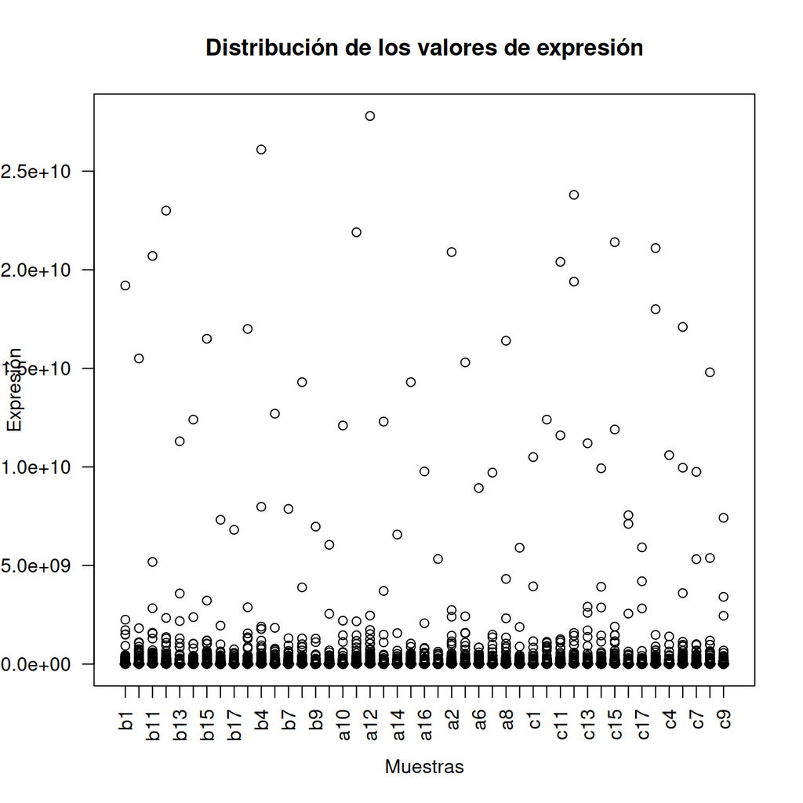

```r
> # Boxplot de los valores de expresion.
> boxplot(assay(sumEx), las=2, col="lightblue",
+         main="Distribución de los valores de expresión",
+         xlab="Muestras", ylab="Expresión")
```

Podemos observar que en el primer boxplot se muestran valores de expresión altamente asimétricos, por lo que nos ayudaremos de realizar una transformación logarítmica para estabilizar la varianza.

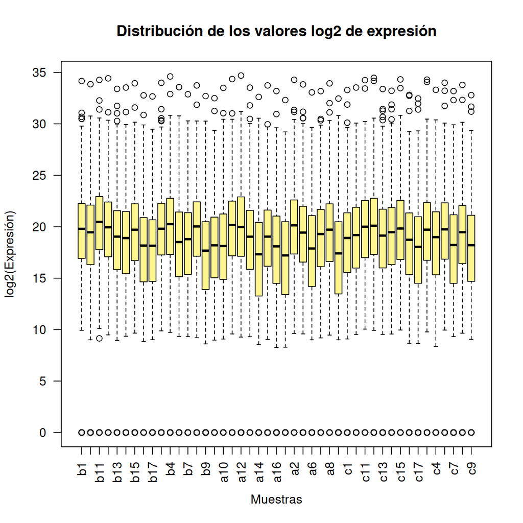

```r
> # Realizamos una transformacion logaritmica para mejorar la simetria.
> logExpr <- log2(assay(sumEx) + 1) # Sumamos 1 para evitar log(0).
>
> # Boxplot despues de la transformacion logaritmica.
> boxplot(logExpr, las=2, col="khaki1",
+         main="Distribución de los valores log2 de expresión",
+         xlab="Muestras", ylab="log2(Expresión)")
```

**3.2 Análisis Multivariante.**

Análisis de Componentes Principales (PCA).

```r
> # Eliminacion de valores valores problematicos, NA, NaN o Inf.
> logExprClean <- logExpr[!apply(is.na(logExpr) | is.nan(logExpr) | is.infinite(logExpr), 1, any), ]
```

```r
> # Calculamos PCA con datos transformados.
> pcaRes <- prcomp(t(logExprClean), scale=TRUE)
> # Mostramos la proporcion de varianza explicada.
> summary(pcaRes)
```

```
Importance of components:
                           PC1     PC2    PC3     PC4     PC5     PC6    PC7
Standard deviation     21.1059 8.51183 7.8372 7.22652 6.69111 6.46277 6.2447
Proportion of Variance  0.3278 0.05331 0.0452 0.03843 0.03294 0.03073 0.0287
Cumulative Proportion   0.3278 0.38110 0.4263 0.46472 0.49766 0.52840 0.5571
                           PC8     PC9    PC10   PC11    PC12    PC13   PC14
Standard deviation     6.14077 5.66862 5.46416 5.3550 5.09402 5.02428 4.7917
Proportion of Variance 0.02775 0.02364 0.02197 0.0211 0.01909 0.01857 0.0169
Cumulative Proportion  0.58484 0.60849 0.63046 0.6516 0.67065 0.68923 0.7061
                          PC15    PC16    PC17    PC18    PC19    PC20   PC21
Standard deviation     4.77247 4.51351 4.41275 4.38252 4.22944 4.19221 4.1380
Proportion of Variance 0.01676 0.01499 0.01433 0.01413 0.01316 0.01293 0.0126
Cumulative Proportion  0.72288 0.73787 0.75220 0.76633 0.77949 0.79243 0.8050
                          PC22    PC23    PC24    PC25    PC26    PC27    PC28
Standard deviation     4.03994 3.99343 3.85060 3.79178 3.71474 3.66260 3.59749
Proportion of Variance 0.01201 0.01173 0.01091 0.01058 0.01015 0.00987 0.00952
Cumulative Proportion  0.81704 0.82877 0.83968 0.85026 0.86041 0.87029 0.87981
                          PC29    PC30    PC31    PC32    PC33    PC34    PC35
Standard deviation     3.58441 3.49830 3.43583 3.41658 3.37668 3.32994 3.29295
Proportion of Variance 0.00945 0.00901 0.00869 0.00859 0.00839 0.00816 0.00798
Cumulative Proportion  0.88926 0.89827 0.90695 0.91554 0.92393 0.93209 0.94007
                          PC36    PC37   PC38    PC39    PC40    PC41    PC42
Standard deviation     3.26211 3.20762 3.1711 3.11550 3.02845 2.94591 2.84585
Proportion of Variance 0.00783 0.00757 0.0074 0.00714 0.00675 0.00639 0.00596
Cumulative Proportion  0.94790 0.95547 0.9629 0.97002 0.97676 0.98315 0.98911
                          PC43    PC44      PC45
Standard deviation     2.77278 2.66686 9.689e-14
Proportion of Variance 0.00566 0.00523 0.000e+00
Cumulative Proportion  0.99477 1.00000 1.000e+00
```

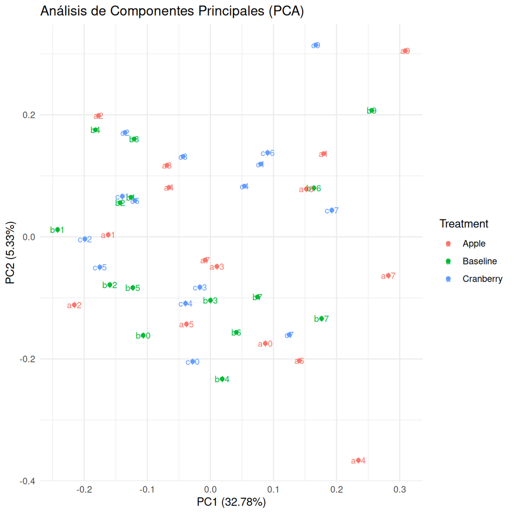

```r
> # Realizamos la grafica del PCA.
> autoplot(pcaRes, data = as.data.frame(colData(sumEx)),
+          colour = "Treatment", label = TRUE, label.size = 3) +
+   ggtitle("Análisis de Componentes Principales (PCA)") +
+   theme_minimal()
```

Si los grupos experimentales se separan en el PCA, significa que la variabilidad se asocia con los tratamientos. Si hay solapamiento, pueden existir otras fuentes de variabilidad como efectos batch.

**3.3 Agrupamiento jerárquico.**

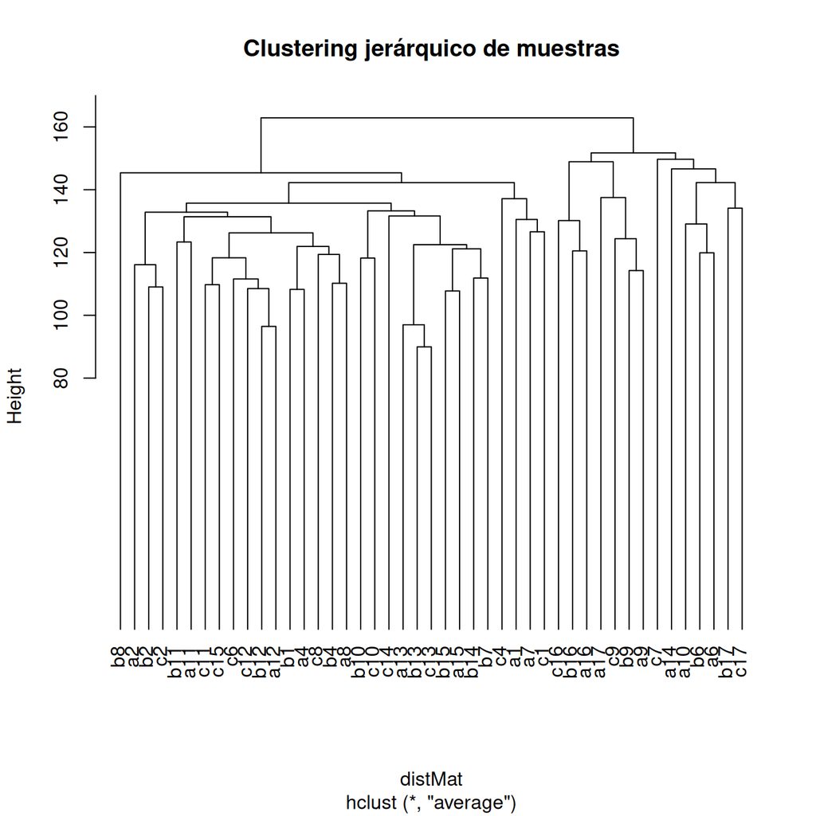

```r
> # Realizamos una matriz de distancias y clustering jerarquico.
> distMat <- dist(t(logExpr))
> hc <- hclust(distMat, method="average")
>
> # Generamos el dendrograma.
> plot(hc, main="Clustering jerárquico de muestras", hang=-1)
```

Si las muestras del mismo grupo experimental se agrupan juntas en el dendrograma, es una buena señal de que los datos reflejan las condiciones biológicas esperadas. Si hay mezclas inesperadas, podría haber problemas técnicos o efectos batch.

### 4. Referencias.

**[1]** *metaboData/Datasets/2024-fobitools-UseCase_1 at main · nutrimetabolomics/metaboData*. (n.d.). Retrieved April 2, 2025, from [https://github.com/nutrimetabolomics/metaboData/tree/main/Datasets/2024-fobitools-UseCase_1](https://github.com/nutrimetabolomics/metaboData/tree/main/Datasets/2024-fobitools-UseCase%E2%82%81)